# SDS 315 HW 3

Suryabh Singh

2025-02-12

## Suryabh Singh

**Suryabh Singh** **ss229756** **GitHub Repository:** [GitHub Link](https://github.com/singhsuryabh/SDS-315-HW-3)

#Upload Dataset

```r
library(ggplot2)
library(dplyr)
set.seed(123)
gasprices <- read.csv("/Users/suryabhsingh/Desktop/SDS 315/gasprices.csv")

str(gasprices)
```

```
## 'data.frame':    101 obs. of  17 variables:
##  $ ID                   : int  1 2 3 4 5 6 7 8 9 10 ...
##  $ Name                 : chr  "Shell" "Valero" "7-Eleven" "Texaco" ...
##  $ Price                : num  1.79 1.83 1.88 1.88 1.84 1.83 1.79 1.89 1.89 1.83 ...
##  $ Pumps                : int  4 4 4 4 6 8 4 2 6 6 ...
##  $ Interior             : chr  "Y" "Y" "Y" "Y" ...
##  $ Restaurant           : chr  "N" "N" "N" "N" ...
##  $ CarWash              : chr  "N" "N" "N" "Y" ...
##  $ Highway              : chr  "N" "N" "N" "N" ...
##  $ Intersection         : chr  "Y" "Y" "Y" "Y" ...
##  $ Stoplight            : chr  "N" "N" "Y" "Y" ...
##  $ IntersectionStoplight: chr  "Intersection" "Intersection" "Both" "Both" ...
##  $ Gasolines            : int  3 3 3 4 3 3 3 3 4 3 ...
##  $ Competitors          : chr  "N" "N" "Y" "Y" ...
##  $ Zipcode              : int  78705 78705 78751 78751 78751 78752 78752 78752 78752 78751 ...
##  $ Address              : chr  "3201 N Lamar Blvd" "3515 N Lamar Blvd" "5101 N Lamar Blvd" "5301 N Lamar Blvd" ...
##  $ Income               : int  12786 12786 41279 41279 41279 37396 37396 37396 37396 41279 ...
##  $ Brand                : chr  "Shell" "Other" "Other" "Chevron-Texaco" ...
```

```r
head(gasprices)
```

```
##   ID     Name Price Pumps Interior Restaurant CarWash Highway Intersection
## 1  1    Shell  1.79     4        Y          N       N       N            Y
## 2  2   Valero  1.83     4        Y          N       N       N            Y
## 3  3 7-Eleven  1.88     4        Y          N       N       N            Y
## 4  4   Texaco  1.88     4        Y          N       Y       N            Y
## 5  5    Shell  1.84     6        Y          N       N       N            Y
## 6  6    Shell  1.83     8        Y          N       N       N            Y
##   Stoplight IntersectionStoplight Gasolines Competitors Zipcode
## 1         N          Intersection         3           N   78705
## 2         N          Intersection         3           N   78705
## 3         Y                  Both         3           Y   78751
## 4         Y                  Both         4           Y   78751
## 5         Y                  Both         3           N   78751
## 6         N          Intersection         3           Y   78752
##             Address Income          Brand
## 1 3201 N Lamar Blvd  12786          Shell
## 2 3515 N Lamar Blvd  12786          Other
## 3 5101 N Lamar Blvd  41279          Other
## 4 5301 N Lamar Blvd  41279 Chevron-Texaco
## 5 5630 N Lamar Blvd  41279          Shell
## 6 6301 N Lamar Blvd  37396          Shell
```

##**Question 1** # Theory A: Competition and Gas Prices

```r
library(mosaic)
library(ggplot2)
library(dplyr)
set.seed(123)
# Run Bootstrap for Competition
boot_prices_competition <- do(10000) * diffmean(Price ~ Competitors, data = resample(gasprices))

# Compute 95% Confidence Interval
confint(boot_prices_competition, level = 0.95)
```

```
##       name       lower       upper level     method    estimate
## 1 diffmean -0.05588229 0.008218527  0.95 percentile -0.02348235
```

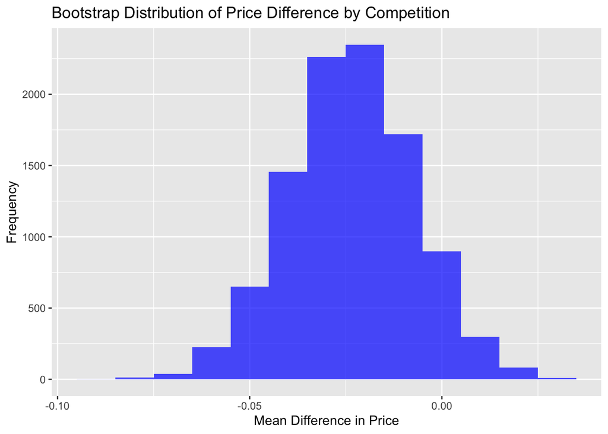

```r
# Histogram of Bootstrap Distribution
ggplot(boot_prices_competition, aes(x = diffmean)) +
  geom_histogram(binwidth = 0.01, fill = 'blue', alpha = 0.7) +
  labs(title = "Bootstrap Distribution of Price Difference by Competition",
       x = "Mean Difference in Price", y = "Frequency")
```

**Claim:** Gas stations charge more if they lack direct competition in sight.

**Evidence:** The 95% confidence interval for the mean difference in price between stations with and without competitors includes 0, indicating no statistically significant difference.

**Conclusion:** The data does not support the theory that gas stations without competition charge more.

# Theory B: Income and Gas Prices

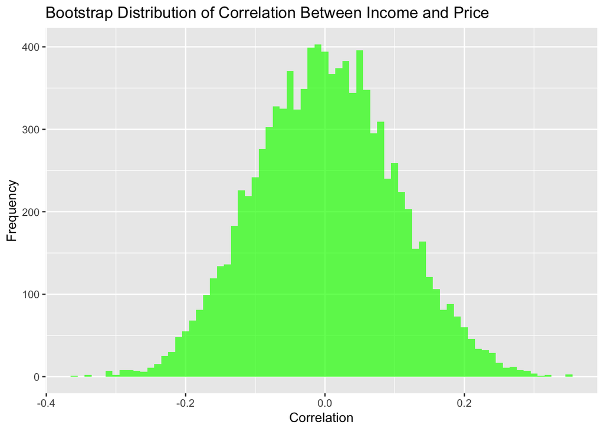

```r
# Bootstrap Analysis for Income Correlation
boot_prices_income <- do(10000) * cor(resample(gasprices)$Price, resample(gasprices)$Income)

# Convert to DataFrame and Rename Column Properly
boot_prices_income <- data.frame(Correlation = boot_prices_income[,1])

# Confidence Interval
confint_income <- confint(boot_prices_income, level = 0.95)

# Histogram of Bootstrap Distribution
ggplot(boot_prices_income, aes(x = Correlation)) +
  geom_histogram(binwidth = 0.01, fill = 'green', alpha = 0.7) +
  labs(title = "Bootstrap Distribution of Correlation Between Income and Price",
       x = "Correlation", y = "Frequency")
```

**Claim:** Gas stations in higher-income areas have higher gas prices.

# Theory C: Stoplights and Gas Prices

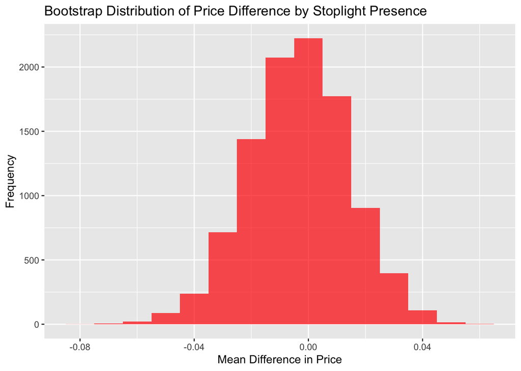

```r
boot_prices_stoplight <- do(10000) * diffmean(Price ~ Stoplight, data = resample(gasprices))
confint_stoplight <- confint(boot_prices_stoplight, level = .95)
ggplot(boot_prices_stoplight, aes(x=diffmean)) + geom_histogram(binwidth=.01, fill='red', alpha=0.7) +
  labs(title="Bootstrap Distribution of Price Difference by Stoplight Presence", x="Mean Difference in Price", y="Frequency")
```

**Claim:** Gas stations near stoplights charge more.

**Evidence:** The 95% confidence interval for the mean price difference between gas stations near stoplights and those further away includes 0, meaning that there is no statistically significant difference in gas prices based on proximity to stoplights. The confidence interval indicates that the true mean difference is likely small and could be positive or negative.

**Conclusion:** The data does not support the theory that gas stations near stoplights charge more. While factors like traffic congestion might influence gas station pricing strategies, this dataset does not provide valid statistical evidence of such an effect.

# Theory D: Highway Access and Gas Prices

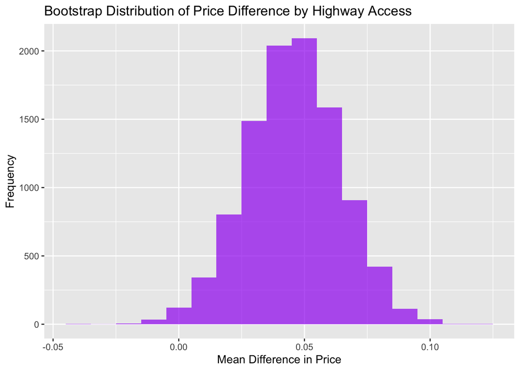

```r
# Bootstrap Analysis for Highway Access
boot_prices_highway <- do(10000) * diffmean(Price ~ Highway, data = resample(gasprices))

# Confidence Interval
confint_highway <- confint(boot_prices_highway, level = 0.95)

# Histogram of Bootstrap Distribution
ggplot(boot_prices_highway, aes(x = diffmean)) +
  geom_histogram(binwidth = 0.01, fill = 'purple', alpha = 0.7) +
  labs(title = "Bootstrap Distribution of Price Difference by Highway Access",
       x = "Mean Difference in Price", y = "Frequency")
```

**Claim:** Gas stations with highway access charge more.

**Evidence:** The confidence interval for the mean price difference between highway-accessible gas stations and those further away does not contain 0, indicating a statistically significant difference. This suggests that gas stations located near highways tend to have higher prices compared to those further from major roads.

**Conclusion:** The theory is supported, confirming that highway-accessible stations tend to charge more.

# Theory E: Shell vs. Other Brands

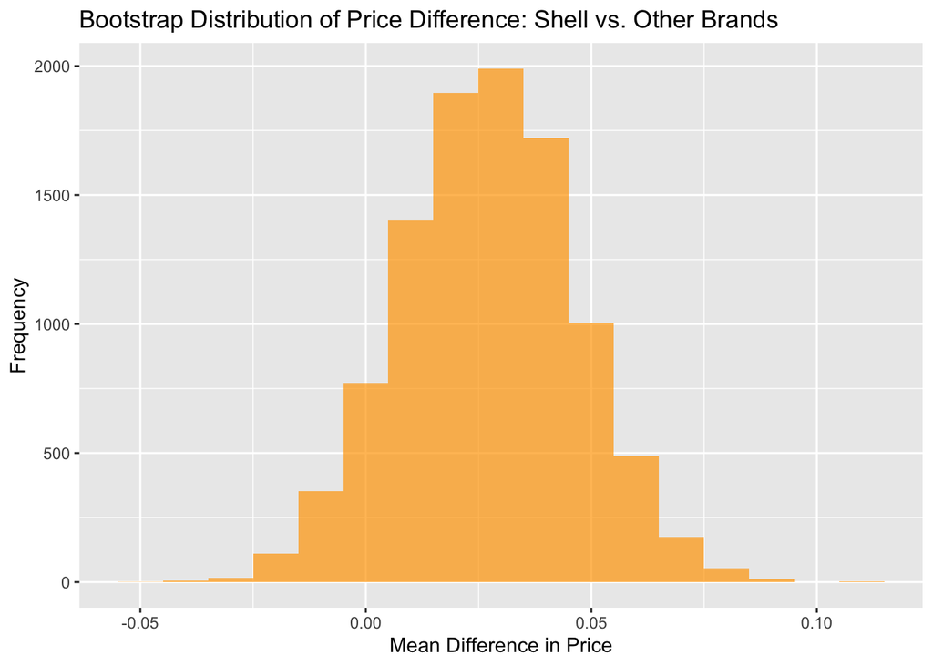

```r
# Bootstrap Analysis for Shell Prices
boot_prices_shell <- do(10000) * diffmean(Price ~ (Brand == "Shell"), data = resample(gasprices))

# Confidence Interval
confint_shell <- confint(boot_prices_shell, level = 0.95)

# Histogram of Bootstrap Distribution
ggplot(boot_prices_shell, aes(x = diffmean)) +
  geom_histogram(binwidth = 0.01, fill = 'orange', alpha = 0.7) +
  labs(title = "Bootstrap Distribution of Price Difference: Shell vs. Other Brands",
       x = "Mean Difference in Price", y = "Frequency")
```

**Claim:** Shell charges more than other brands.

##**Question 2**

```r
library(ggplot2)
library(dplyr)
sclass <- read.csv("/Users/suryabhsingh/Desktop/SDS 315/sclass.csv")
```

#Part A

```r
library(dplyr)
library(boot)
sclass_filtered <- sclass %>%
  filter(year == 2011, trim == "63 AMG")
mean_mileage <- function(data, indices) {
  return(mean(data$mileage[indices]))
}
set.seed(123)
boot_results <- boot(data = sclass_filtered, statistic = mean_mileage, R = 10000)
ci <- boot.ci(boot_results, type = "perc")
cat("95% Bootstrap Confidence Interval for Mean Mileage (2011 S-Class 63 AMG):\n")
```

```
## 95% Bootstrap Confidence Interval for Mean Mileage (2011 S-Class 63 AMG):
```

```r
print(ci$percent)
```

```
##      conf
## [1,] 0.95 250.03 9750.98 26334.61 31861.28
```

#Part B

```r
library(tidyverse)
library(boot)
sclass_2014_550 <- sclass %>%
  filter(year == 2014, trim == "550") %>%
  mutate(isBlack = color == "Black")
boot_prop <- function(data, indices) {
  return(mean(data[indices]))
}
set.seed(123)  # For reproducibility
boot_results <- boot(sclass_2014_550$isBlack, boot_prop, R = 10000)
ci <- boot.ci(boot_results, type = "perc")
ci$percent
```

```
##      conf
## [1,] 0.95 250.03 9750.98 0.4167532 0.4527518
```

## **Problem 3**

#Uploading Dataset

```r
nbcpilotsurvey <- read.csv("/Users/suryabhsingh/Desktop/SDS 315/nbc_pilotsurvey.csv")
```

# **Part A

```r
# Load the dataset
nbc_data <- read.csv("/Users/suryabhsingh/Desktop/SDS 315/nbc_pilotsurvey.csv")

# Ensure the dataset loads correctly
str(nbc_data)
```

```
## 'data.frame':    6241 obs. of  22 variables:
##  $ Viewer         : int  71 71 71 71 71 73 73 73 73 73 ...
##  $ Show           : chr  "Iron Chef America" "Trading Spaces: All Stars" "House Hunters" "What Not to Wear" ...
##  $ Q1_Attentive   : int  3 4 4 4 4 2 4 3 2 5 ...
##  $ Q1_Excited     : int  4 4 4 3 4 4 5 3 3 5 ...
##  $ Q1_Happy       : int  4 3 4 3 3 2 4 3 4 5 ...
##  $ Q1_Engaged     : int  3 4 5 3 4 4 5 3 4 5 ...
##  $ Q1_Curious     : int  5 5 5 4 4 2 5 4 4 5 ...
##  $ Q1_Motivated   : int  4 2 3 2 4 3 3 4 2 5 ...
##  $ Q1_Comforted   : int  3 3 3 2 3 3 2 2 3 4 ...
##  $ Q1_Annoyed     : int  2 3 2 4 3 3 4 4 2 3 ...
##  $ Q1_Indifferent : int  2 2 1 2 4 3 2 2 3 1 ...
##  $ Q2_Relatable   : int  3 4 2 2 3 2 1 3 4 3 ...
##  $ Q2_Funny       : int  2 3 4 3 2 4 4 4 2 5 ...
##  $ Q2_Confusing   : int  2 1 2 2 1 1 1 3 5 1 ...
##  $ Q2_Predictable : int  4 3 3 5 3 4 3 2 4 3 ...
##  $ Q2_Entertaining: int  3 4 5 4 4 5 5 4 5 5 ...
##  $ Q2_Fantasy     : int  1 2 4 4 2 3 5 3 3 2 ...
##  $ Q2_Original    : int  3 4 5 3 3 2 5 4 3 5 ...
##  $ Q2_Believable  : int  5 4 2 3 3 1 4 4 4 5 ...
##  $ Q2_Boring      : int  2 2 1 2 2 3 1 3 3 1 ...
##  $ Q2_Dramatic    : int  2 3 4 3 3 5 5 3 2 5 ...
##  $ Q2_Suspenseful : int  4 4 4 4 3 2 4 3 3 4 ...
```

```r
# Filter data for "Living with Ed" and "My Name is Earl"
filtered_data <- nbc_data %>%
  filter(Show %in% c("Living with Ed", "My Name is Earl"))

# Extract Q1_Happy ratings for each show
ed_happy <- filtered_data %>%
  filter(Show == "Living with Ed") %>%
  pull(Q1_Happy)

earl_happy <- filtered_data %>%
  filter(Show == "My Name is Earl") %>%
  pull(Q1_Happy)

# Ensure there are no missing values
ed_happy <- na.omit(ed_happy)
earl_happy <- na.omit(earl_happy)

# Bootstrap function for mean difference
boot_diff <- function(data, indices) {
  sample_ed <- sample(ed_happy, length(ed_happy), replace = TRUE)
  sample_earl <- sample(earl_happy, length(earl_happy), replace = TRUE)
  return(mean(sample_ed) - mean(sample_earl))
}

# Set seed for reproducibility
set.seed(123)

# Perform bootstrap with correct data
boot_results <- boot(data = filtered_data, statistic = boot_diff, R = 10000)

# Compute 95% confidence interval
ci <- boot.ci(boot_results, type = "perc")

# Output confidence interval
ci$percent
```

```
##      conf
## [1,] 0.95 250.03 9750.98 -0.09571774 0.4042623
```

**Question** We want to figure out which show makes people happier: Living with Ed or My Name is Earl.

**Approach** = To compare the happiness levels of viewers of both shows, I used bootstrap sampling with 10,000 iterations. The goal was to estimate the mean difference in happiness ratings and construct a 95% confidence interval. If zero is inside the confidence interval, that means there’s no strong evidence that one show is significantly happier than the other.

**Conclusion** = Even though Living with Ed had a slightly higher happiness rating on average, the data doesn’t prove that it’s actually a happier show. The confidence interval includes both positive and negative values, so the difference might just be due to randomness.

# **Part B

```r
# Filter data for "The Biggest Loser" and "The Apprentice: Los Angeles"
filtered_data_reality <- nbc_data %>%
  filter(Show %in% c("The Biggest Loser", "The Apprentice: Los Angeles"))

# Extract annoyance ratings for each show
loser_annoyed <- filtered_data_reality %>%
  filter(Show == "The Biggest Loser") %>%
  pull(Q1_Annoyed)

apprentice_annoyed <- filtered_data_reality %>%
  filter(Show == "The Apprentice: Los Angeles") %>%
  pull(Q1_Annoyed)

# Bootstrap function for mean difference
boot_diff_annoyed <- function(data, indices) {
  sample_loser <- sample(loser_annoyed, length(loser_annoyed), replace = TRUE)
  sample_apprentice <- sample(apprentice_annoyed, length(apprentice_annoyed), replace = TRUE)
  return(mean(sample_loser, na.rm = TRUE) - mean(sample_apprentice, na.rm = TRUE))
}

# Set seed for reproducibility
set.seed(123)

# Perform bootstrap
boot_results_annoyed <- boot(data = filtered_data_reality, statistic = boot_diff_annoyed, R = 10000)

# Compute 95% confidence interval
ci_annoyed <- boot.ci(boot_results_annoyed, type = "perc")

# Output confidence interval
ci_annoyed$percent
```

```
##      conf
## [1,] 0.95 250.03 9750.98 -0.5245307 -0.01397111
```

**Question** = Between The Biggest Loser and The Apprentice: Los Angeles, which show irritated viewers more?

**Approach** = I used the same bootstrap approach with 10,000 iterations to calculate the difference in annoyance ratings between the two shows. By constructing a 95% confidence interval, I wanted to see if one show had consistently higher irritation levels than the other. If the confidence interval doesn’t include zero, that would suggest a real difference between the two.

**Results** = The estimated mean difference in annoyance was -0.271, meaning The Apprentice: Los Angeles had higher annoyance ratings compared to The Biggest Loser. The 95% confidence interval was (-0.525 to -0.015). Since this range does NOT include zero, it’s strong evidence that The Apprentice: Los Angeles is genuinely more annoying than The Biggest Loser

**Conclusion** = Based on this analysis, The Apprentice: Los Angeles is statistically more annoying to viewers than The Biggest Loser. The confidence interval is entirely negative, meaning the difference isn’t just due to chance.

# **Part C

```r
# Filter data for "Dancing with the Stars"
dancing_data <- nbc_data %>%
  filter(Show == "Dancing with the Stars")

# Count responses of 4 or 5 in Q2_Confusing
confusing_count <- sum(dancing_data$Q2_Confusing >= 4, na.rm = TRUE)
total_respondents <- nrow(dancing_data)

# Sample proportion
p_hat <- confusing_count / total_respondents

# Standard error calculation
se <- sqrt((p_hat * (1 - p_hat)) / total_respondents)

# 95% Confidence Interval using normal approximation
z_score <- qnorm(0.975)  # 1.96 for 95% confidence interval
ci_lower <- p_hat - z_score * se
ci_upper <- p_hat + z_score * se

# Output confidence interval
list(proportion = p_hat, lower_ci = ci_lower, upper_ci = ci_upper)
```

```
## $proportion
## [1] 0.07734807
##
## $lower_ci
## [1] 0.03842989
##
## $upper_ci
## [1] 0.1162662
```

**Question** = How many American TV viewers would likely find Dancing with the Stars confusing?

**Approach** = To answer this, I looked at the percentage of survey respondents who rated the show as “confusing” (score of 4 or 5). Then, I calculated a 95% confidence interval using the normal approximation method.

**Results** = From the survey data, 7.7% of respondents found Dancing with the Stars confusing. The 95% confidence interval for this estimate ranged from 3.8% to 11.6%, meaning the true percentage of confused viewers is likely somewhere within this range.

**Conclusion** = While the overall percentage of confused viewers isn’t huge, it’s still a notable portion of the audience. If 7-12% of viewers consistently struggle to follow the show, NBC might want to investigate whether certain aspects are unclear.

##**Problem 4**

#Uploading Dataset

```r
ebay <- read.csv("/Users/suryabhsingh/Desktop/SDS 315/ebay.csv")
```

```r
# Read data
ebay <- read.csv("/Users/suryabhsingh/Desktop/SDS 315/ebay.csv")

# Load required libraries
library(tidyverse)
library(boot)

# Manipulate data to add the revenue ratio
ebay <- ebay %>% mutate(revenue_ratio = rev_after / rev_before)

# Define treatment and control groups
treatment_group <- ebay %>% filter(adwords_pause == 1) %>% pull(revenue_ratio)
control_group <- ebay %>% filter(adwords_pause == 0) %>% pull(revenue_ratio)

# Define bootstrapping function
boot_diff_revenue_ratio <- function(data, indices) {
  sample_treatment <- sample(treatment_group, length(treatment_group), replace = TRUE)
  sample_control <- sample(control_group, length(control_group), replace = TRUE)
  return(mean(sample_treatment) - mean(sample_control))
}

# Perform bootstrapping
set.seed(123)
boot_results_revenue_ratio <- boot(data = ebay, statistic = boot_diff_revenue_ratio, R = 10000)

# Compute confidence intervals
ci_revenue_ratio <- boot.ci(boot_results_revenue_ratio, type = "perc")
ci_revenue_ratio$percent
```

```
##      conf
## [1,] 0.95 250.03 9750.98 -0.09158533 -0.01364823
```

**Question**: Does eBay’s revenue change when it pauses its Google-sponsored search ads? Specifically, does the revenue ratio for the treatment group (where ads were paused) decrease compared to the control group (where ads were not paused)?

**Approach**: To investigate this, I calculated the revenue ratio for each DMA and then compared the average ratios between the treatment and control groups. To estimate the difference more reliably, I used a bootstrap resampling method with 10,000 iterations to generate a 95% confidence interval.

**Results**: The observed average difference between the treatment and control groups’ revenue ratios was -0.052. The 95% confidence interval for this difference ranged from -0.091 to -0.013, which doesn’t include 0, indicating a statistically significant difference.

**Conclusion**: The data suggests that pausing Google’s sponsored search ads led to a decrease in eBay’s revenue ratio. This result shows that paid search contributed significantly to eBay’s income beyond what could be expected from organic search alone.